# Final Report

### 注：用集成方法Importance选变量放入LR?

```r
######################
#按照选出来的变量再加入到LR中？
LRRF1<-glm(Ytrain01~Gzma+Calr+Tiam2+Nt5c3+X1110004F10Rik+Zeb1+Pofut1
                    ,data=train,family = 'binomial')
summary(LRRF1)
```

```
##
## Call:
## glm(formula = Ytrain01 ~ Gzma + Calr + Tiam2 + Nt5c3 + X1110004F10Rik +
##     Zeb1 + Pofut1, family = "binomial", data = train)
##
## Deviance Residuals:
##      Min        1Q    Median        3Q       Max
## -2.28553   0.00016   0.00164   0.01449   1.35617
##
## Coefficients:
##                Estimate Std. Error z value Pr(>|z|)
## (Intercept)      -4.384      2.619  -1.674  0.09413 .
## Gzma             -6.634      2.350  -2.823  0.00476 **
## Calr              7.251      2.955   2.454  0.01412 *
## Tiam2            -8.590      3.557  -2.415  0.01573 *
## Nt5c3             6.395      2.593   2.466  0.01367 *
## X1110004F10Rik   -2.199      1.648  -1.335  0.18201
## Zeb1             -5.638      2.634  -2.140  0.03232 *
## Pofut1           -2.138      1.876  -1.140  0.25437
## ---
## Signif. codes:  0 '***' 0.001 '**' 0.01 '*' 0.05 '.' 0.1 ' ' 1
##
## (Dispersion parameter for binomial family taken to be 1)
##
##     Null deviance: 99.075  on 279  degrees of freedom
## Residual deviance: 21.679  on 272  degrees of freedom
## AIC: 37.679
##
## Number of Fisher Scoring iterations: 11
```

```r
LRRF<-step(LRRF1)
```

```
## Start:  AIC=37.68
## Ytrain01 ~ Gzma + Calr + Tiam2 + Nt5c3 + X1110004F10Rik + Zeb1 +
##     Pofut1
##
##                  Df Deviance    AIC
## - Pofut1          1   22.995 36.995
## - X1110004F10Rik  1   23.555 37.555
## <none>                21.679 37.679
## - Zeb1            1   28.405 42.405
## - Tiam2           1   33.442 47.442
## - Gzma            1   36.646 50.646
## - Nt5c3           1   41.037 55.037
## - Calr            1   48.523 62.523
##
## Step:  AIC=37
## Ytrain01 ~ Gzma + Calr + Tiam2 + Nt5c3 + X1110004F10Rik + Zeb1
##
##                  Df Deviance    AIC
## <none>                22.995 36.995
## - X1110004F10Rik  1   25.522 37.522
## - Zeb1            1   32.429 44.429
## - Tiam2           1   36.777 48.777
## - Gzma            1   37.859 49.859
## - Nt5c3           1   43.955 55.955
## - Calr            1   52.392 64.392
```

```r
LRRF.pred<-predict(LRRF,test,type='response')
LRRF.pred2<-prediction(LRRF.pred,Ytest01)
perfLRRF<-performance(LRRF.pred2,'sens','spec')
#perfLRRF@x.values#speci
#perfLRRF@y.values#TPR
performance(LRRF.pred2,'auc')@y.values
```

```
## [[1]]
## [1] 0.7189055
```

```r
#AUC达到0.71，这说明其实和前面的方法差别是非常大的
```

### 备注：

shrinkage+LR的效果和集成importance+LR效果差别挺大，不是一个体系的。同时后者可能是非线性的关系，不能直接放在glm

不如尝试XGBOOST非线性one hot encoding后再加入到LR的方法！

## 开始解决非平衡问题

注：按照网站https://blog.csdn.net/a358463121/article/details/52304670 的方法一个个试。还有 https://blog.csdn.net/heyongluoyao8/article/details/49408131

非平衡数据的分类学习是机器学习和数据挖掘中的重要问题。解决该问题最直接的方法是采用一定的方法使数据集变得平衡。目前主要针对二类分类问题，将算法扩展为能呈现多类分类形式，是未来需深入研究的问题。同时，如何区别少数类数据和噪声数据，也有待进一步研究。

首先，在非平衡问题不解决前，所有树方法、SVM方法都是不能用的。

不平衡问题，用几种方法改进：

1.（略）改进分类器：如代价敏感方法——总之采取过拟合可能性比较低的算法

2.改变样本分布，先试试简单暴力的bootstrap，和采取如过采样方法，比如SMOTE、ADASYN

3.（已做）集成学习解决？——但基学习器不能用树

4.组合方法，如SMOTE等采样（过/欠）+SVM的分类器+XGBOOST集成组合

5.（略）其他类型做法：杠杆、异常点检测，泛化能力更好，单类SVM检测（第二大类）。

6.非机器学习做法，———FDR多重假设检验的新思路（第三大类），属于接下来的做法！

详情引用——胡杰老师的Imblanced文件夹

这里我们主要使用的是SMOTE采样方法：

### SMOTE+预处理

```r
#################
#SMOTE
#################

dataSMOTE<-train
class(dataSMOTE$Ytrain01)
```

```
## [1] "factor"
```

```r
table(dataSMOTE$Ytrain01)
```

```
##
##   0   1
##  12 268
```

```r
dim(dataSMOTE)
```

```
## [1]  280 6594
```

```r
## now using SMOTE to create a more "balanced problem"
set.seed(1)
dataSMOTE1 <- SMOTE(Ytrain01 ~ ., dataSMOTE,perc.over = 1900,perc.under = 105,k=5)

table(dataSMOTE1$Ytrain01)
```

```
##
##   0   1
## 240 239
```

```r
dim(dataSMOTE1)#过采样后，变成了479个数！
```

```
## [1]  479 6594
```

```r
#################
#准备工作
set.seed(1)
YSMOTE<-dataSMOTE1$Ytrain01
Y01.SMOTE<-rep(0,length(YSMOTE))
Y01.SMOTE[YSMOTE=='1']<-1


XX.SMOTE<-dataSMOTE1[,2:ncol(dataSMOTE1)]
length00<-function(X){
  return(sum(X!=0))#n=479减去0的个数
}
X.SMOTE<-XX.SMOTE[,which(apply(XX.SMOTE,2,length00)>=0.05*479)]
dim(X.SMOTE)
```

```
## [1]  479 6021
```

```r
Xscale.SMOTE<-scale(X.SMOTE)
testnum.smote<-sample(1:479,120,replace = F)

Ytrain01.SMOTE<-Y01.SMOTE[-testnum.smote]
Ytest01.SMOTE<-Y01.SMOTE[testnum.smote]
Xtest.SMOTE<-X.SMOTE[testnum.smote,]
Xtrain.SMOTE<-X.SMOTE[-testnum.smote,]
Xtestscale.SMOTE<-Xscale.SMOTE[testnum.smote,]
Xtrainscale.SMOTE<-Xscale.SMOTE[-testnum.smote,]
```

SMOTE过后，原始数据变成了239:240，总共约等于480个数.以此基础120个为测试集，359为训练集划分。

SMOTE函数参数可以解释一下： https://blog.csdn.net/jiabiao1602/article/details/42392377?locationNum=1&fps=1

问题在于SMOTE后是不是iid的？这里姑且认为是

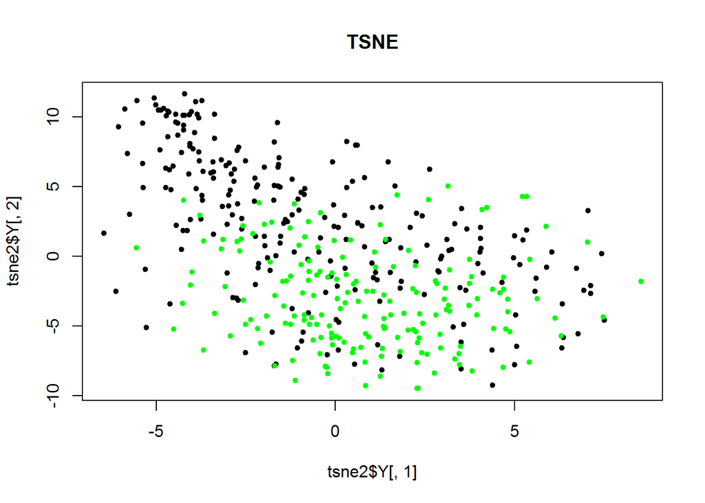

```r
#########SMOTE后的数据
color.SMOTE<-rep('black', length(YSMOTE))
color.SMOTE[which(YSMOTE=='0')]<-'green' #绿色是sham!!!!!!!!!!
set.seed(1)
tsne2<-Rtsne(X,dims = 2)
plot(tsne2$Y[,1],tsne2$Y[,2],main='TSNE',col=color.SMOTE,pch=20)
```

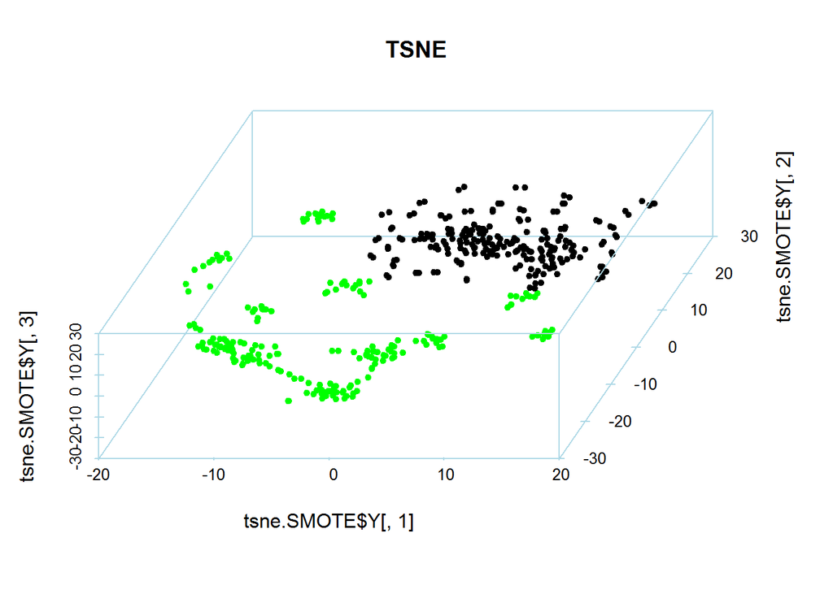

```r
set.seed(1)
tsne.SMOTE<-Rtsne(X.SMOTE,dims = 3,perplexity = 30,check_duplicates = FALSE,verbose=F,max_iter=1000)
scatterplot3d(tsne.SMOTE$Y[,1],tsne.SMOTE$Y[,2],tsne.SMOTE$Y[,3],color=color.SMOTE,
             highlight.3d=F,pch = 20,angle=80,main='TSNE',
              type = 'p',grid = F,col.grid = "lightblue",col.axis = 'lightblue',col.lab = T,
              scale.y =2,xlim = c(-20,20),ylim = c(-25,25),zlim = c(-30,30))
```

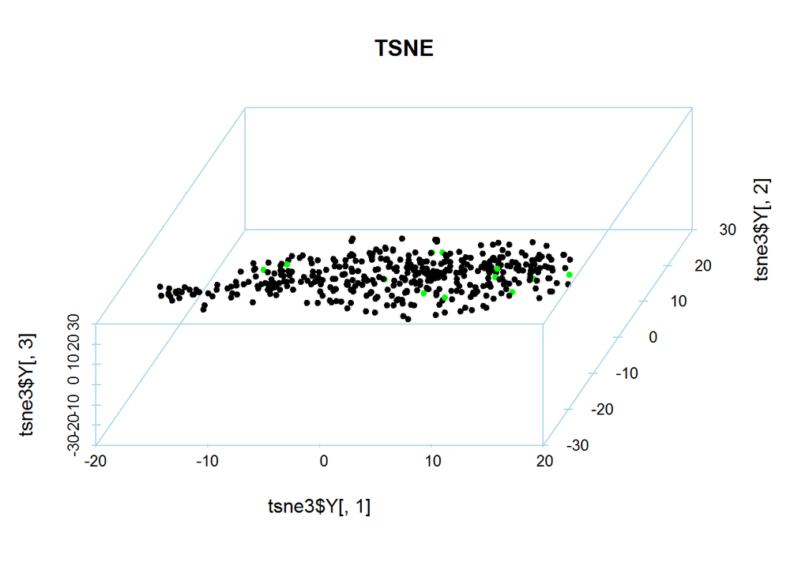

```r
#比较一下原来的
set.seed(1)
tsne3<-Rtsne(X,dims = 3,perplexity = 30,verbose = F,max_iter = 1000)
scatterplot3d(tsne3$Y[,1],tsne3$Y[,2],tsne3$Y[,3],color=color,
              highlight.3d=F,pch = 20,angle=80,main='TSNE',
              type = 'p',grid = F,col.grid = "lightblue",col.axis = 'lightblue',col.lab = T,scale.y =2,xlim = c(-20,20),ylim = c(-25,25),zlim = c(-30,30))
```

```r
## PCA 也看一下
```

问题在于，为何TSNE里绿色———原来的sham，现在分组那么开？难道不应该是CLP有很多类别吗？

注：这里尽量标注出原始sham数据为另一个颜色。看看他们的分布

人工分为sham的部分究竟对不对呢？从TSNE来看，此假设存疑。（此问题解决√，但是CLP分的不开的确也是个问题）

### 之前的分类方法再全部丢进来

```r
#1.elastic net

set.seed(1)
ridge.mod2.SMOTE<-cv.glmnet(Xtrainscale.SMOTE,Ytrain01.SMOTE,alpha=0,family='binomial',type.measure = 'auc')
w.SMOTE<-1/abs(coef(ridge.mod2.SMOTE)[-1])
elastic.mod.SMOTE<-cv.glmnet(Xtrainscale.SMOTE,Ytrain01.SMOTE,alpha=0.8,penalty.factor=w.SMOTE,family='binomial',type.measure = 'auc')
coeffela.SMOTE<-coef(elastic.mod.SMOTE)
sum(coeffela.SMOTE[-1]!=0)
```

```
## [1] 18
```

```r
which(coeffela.SMOTE[-1]!=0)
```

```
##  [1]  356  559  726  804  995 2107 2293 2551 2638 2647 3163 3215 3373 3437
## [15] 3516 4582 4612 4932
```

```r
sum(coeffela.SMOTE[-1]==0)
```

```
## [1] 6003
```

```r
order(abs(coeffela.SMOTE[coeffela.SMOTE!=0]),decreasing = T)
```

```
## <sparse>[ <logic> ] : .M.sub.i.logical() maybe inefficient
```

```
##  [1]  4  8 11  3 17 10 15  9 14 16  6 12  2 13  5  7 18  1 19
```

```r
coeffela.SMOTE@Dimnames[[1]][order(abs(coeffela.SMOTE[coeffela.SMOTE!=0]),decreasing = T)]
```

```
## <sparse>[ <logic> ] : .M.sub.i.logical() maybe inefficient
```

```
##  [1] "X0610012G03Rik" "X1110008F13Rik" "X1110038F14Rik" "X0610010K14Rik"
##  [5] "X1700020I14Rik" "X1110037F02Rik" "X1600012H06Rik" "X1110008P14Rik"
##  [9] "X1600010M07Rik" "X1600014C10Rik" "X0610037L13Rik" "X1110059E24Rik"
## [13] "X0610009O20Rik" "X1110059G10Rik" "X0610030E20Rik" "X1110004F10Rik"
## [17] "X1700020L24Rik" "(Intercept)"    "X1700037H04Rik"
```

```r
pred.elas.SMOTE<-predict(elastic.mod.SMOTE,Xtrainscale.SMOTE,type='response',family='binomial')
pred.elas2.SMOTE<-prediction(pred.elas.SMOTE,Ytrain01.SMOTE)
perfelas.SMOTE<-performance(pred.elas2.SMOTE,'sens','spec')
#perfelas.SMOTE@x.values#
#perfelas.SMOTE@y.values#TPR
performance(pred.elas2.SMOTE,'auc')@y.values#训练集的AUC达到了1
```

```
## [[1]]
## [1] 1
```

```r
pred.elas.SMOTE<-predict(elastic.mod.SMOTE,Xtestscale.SMOTE,type='response',family='binomial')
pred.elas2.SMOTE<-prediction(pred.elas.SMOTE,Ytest01.SMOTE)
perfelas.SMOTE<-performance(pred.elas2.SMOTE,'sens','spec')
#perfelas.SMOTE@x.values#
#perfelas.SMOTE@y.values#TPR
performance(pred.elas2.SMOTE,'auc')@y.values#满分！0.99！！！！！！！！！！
```

```
## [[1]]
## [1] 0.994165
```

```r
auc.elas.SMOTE<-roc(Ytest01.SMOTE,pred.elas.SMOTE)
print(auc.elas.SMOTE)
```

```
##
## Call:
## roc.default(response = Ytest01.SMOTE, predictor = pred.elas.SMOTE)
##
## Data: pred.elas.SMOTE in 61 controls (Ytest01.SMOTE 0) < 59 cases (Ytest01.SMOTE 1).
## Area under the curve: 0.9942
```

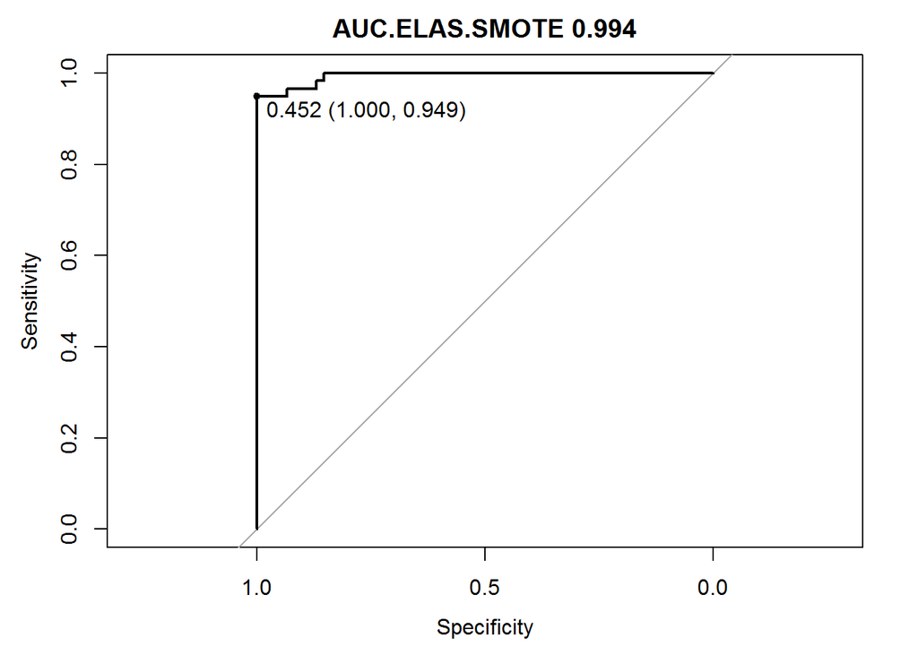

```r
plot(auc.elas.SMOTE,ylim=c(0,1),print.thres=T,main=paste('AUC.ELAS.SMOTE',round(auc.elas.SMOTE$auc[[1]],3)))
```

```r
#2.SCAD
set.seed(1)
scad.mod.SMOTE<-cv.ncvreg(Xtrainscale.SMOTE,Ytrain01.SMOTE,family='binomial',penalty='SCAD')
coeffscad.SMOTE<-coef(scad.mod.SMOTE)

sum(coeffscad.SMOTE[-1]!=0)
```

```
## [1] 30
```

```r
sum(coeffscad.SMOTE[-1]==0)
```

```
## [1] 5991
```

```r
sort(abs(coeffscad.SMOTE[which(coeffscad.SMOTE[-1]!=0)+1]),decreasing = T)
```

```
##        Ccl5        Calr      Lgals3       Hspa5    Gpatch2l       Axin1
## 0.911956672 0.834198109 0.531203207 0.409913614 0.370888291 0.302962819
##        Ipo8        Klf2       Chmp5        Naca     Lilrb4a       Nt5c3
## 0.302559133 0.255345119 0.232704819 0.218894033 0.213885324 0.213119396
##     Serinc3        Apoe       Hacd4        Pbx2      Gtf3c1        Ggt1
## 0.208017113 0.164360133 0.159613549 0.151142581 0.130193937 0.116690098
##        Nkg7       Itga4      Sft2d1     Fam126a        Lsm6       Srsf5
## 0.116442692 0.095317209 0.077975426 0.077103430 0.062937189 0.057594805
##        Ralb     Ppp4r3a        Hps3        Sell       Gsk3b     Fam134b
## 0.041579297 0.028432678 0.014269673 0.008918676 0.005644252 0.000949993
```

```r
pred.scad.SMOTE<-predict(scad.mod.SMOTE,Xtrainscale.SMOTE,type='response',family='binomial')
pred.scad.SMOTE2<-prediction(pred.scad.SMOTE,Ytrain01.SMOTE)#
perfscad.SMOTE<-performance(pred.scad.SMOTE2,'sens','spec')
#perfscad.SMOTE@x.values#specificity
#perfscad.SMOTE@y.values#TPR
performance(pred.scad.SMOTE2,'auc')@y.values#1
```

```
## [[1]]
## [1] 1
```

```r
pred.scad.SMOTE<-predict(scad.mod.SMOTE,Xtestscale.SMOTE,type='response',family='binomial')
pred.scad.SMOTE2<-prediction(pred.scad.SMOTE,Ytest01.SMOTE)#
perfscad.SMOTE<-performance(pred.scad.SMOTE2,'sens','spec')
#perfscad.SMOTE@x.values#specificity
#perfscad.SMOTE@y.values#TPR
performance(pred.scad.SMOTE2,'auc')@y.values#测试集也达到了1...
```

```
## [[1]]
## [1] 1
```

```r
auc.scad.SMOTE<-roc(Ytest01.SMOTE,pred.scad.SMOTE)
print(auc.scad.SMOTE)
```

```
##
## Call:
## roc.default(response = Ytest01.SMOTE, predictor = pred.scad.SMOTE)
##
## Data: pred.scad.SMOTE in 61 controls (Ytest01.SMOTE 0) < 59 cases (Ytest01.SMOTE 1).
## Area under the curve: 1
```

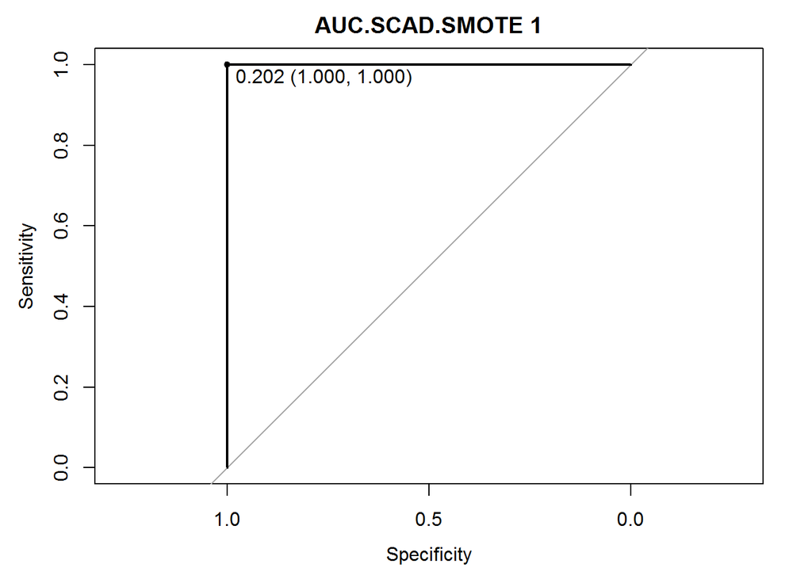

```r
plot(auc.scad.SMOTE,ylim=c(0,1),print.thres=T,main=paste('AUC.SCAD.SMOTE',round(auc.scad.SMOTE$auc[[1]],3)))
```

```r
#3.grplasso
set.seed(1)
grpfit.SMOTE<-grplasso(Ytrain01.SMOTE~., data=cbind(Ytrain01.SMOTE,data.frame(Xtrainscale.SMOTE)),model = LogReg(),lambda = 10)
```

```
## Lambda: 10  nr.var: 32
```

```r
coeffgrp.SMOTE<-coef(grpfit.SMOTE)
sum(coeffgrp.SMOTE[-1]!=0)
```

```
## [1] 31
```

```r
which(coeffgrp.SMOTE[-1]!=0)
```

```
##  [1]  356  559  726  804  995 1484 1731 1955 1969 2052 2089 2107 2142 2273
## [15] 2293 2422 2450 2551 2638 2647 2717 3163 3318 3373 3437 3516 3836 4503
## [29] 4582 4612 4932
```

```r
sum(coeffgrp.SMOTE[-1]==0)
```

```
## [1] 5990
```

```r
order(abs(coeffgrp.SMOTE[coeffgrp.SMOTE!=0]),decreasing = T)
```

```
##  [1]  4 20 16  5  3 21 30 11 17  6 23 14 25 26 19 18 24 31 27 13  7 15  2
## [24] 32 29 22  9  8 28 12 10  1
```

```r
coeffgrp.SMOTE<-data.frame(coeffgrp.SMOTE)
rownames(coeffgrp.SMOTE)[order(abs(coeffgrp.SMOTE[coeffgrp.SMOTE!=0]),decreasing = T)]
```

```
##  [1] "X0610012G03Rik" "X1700047M11Rik" "X1600014C10Rik" "X0610030E20Rik"
##  [5] "X0610010K14Rik" "X1700123O20Rik" "X2210016L21Rik" "X1110038F14Rik"
##  [9] "X1700020I14Rik" "X0610037L13Rik" "X1810022K09Rik" "X1600010M07Rik"
## [13] "X1810030O07Rik" "X1810037I17Rik" "X1700037H04Rik" "X1700020L24Rik"
## [17] "X1810026B05Rik" "X2300009A05Rik" "X1810055G02Rik" "X1110059G10Rik"
## [21] "X1110004F10Rik" "X1600012H06Rik" "X0610009O20Rik" "X2310001H17Rik"
## [25] "X2010107E04Rik" "X1810013L24Rik" "X1110008P14Rik" "X1110008F13Rik"
## [29] "X1810058I24Rik" "X1110059E24Rik" "X1110037F02Rik" "(Intercept)"
```

```r
pred.grp.SMOTE<-predict(grpfit.SMOTE,Xtrainscale.SMOTE,type='response',family='binomial')
auc.grp.SMOTE<-roc(Ytrain01.SMOTE,pred.grp.SMOTE)
print(auc.grp.SMOTE)
```

```
##
## Call:
## roc.default(response = Ytrain01.SMOTE, predictor = pred.grp.SMOTE)
##
## Data: pred.grp.SMOTE in 179 controls (Ytrain01.SMOTE 0) < 180 cases (Ytrain01.SMOTE 1).
## Area under the curve: 1
```

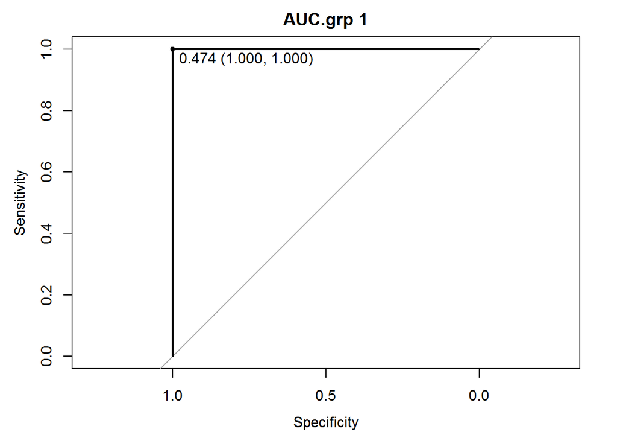

```r
plot(auc.grp.SMOTE,ylim=c(0,1),print.thres=T,main=paste('AUC.grp',round(auc.grp.SMOTE$auc[[1]],3)))
```

```r
pred.grp.SMOTE<-predict(grpfit.SMOTE,Xtestscale.SMOTE,type='response',family='binomial')

auc.grp.SMOTE<-roc(Ytest01.SMOTE,pred.grp.SMOTE)
print(auc.grp.SMOTE)
```

```
##
## Call:
## roc.default(response = Ytest01.SMOTE, predictor = pred.grp.SMOTE)
##
## Data: pred.grp.SMOTE in 61 controls (Ytest01.SMOTE 0) < 59 cases (Ytest01.SMOTE 1).
## Area under the curve: 1
```

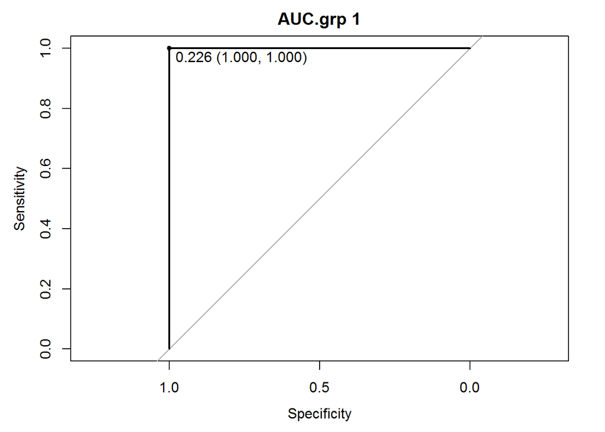

```r
plot(auc.grp.SMOTE,ylim=c(0,1),print.thres=T,main=paste('AUC.grp',round(auc.grp.SMOTE$auc[[1]],3)))
```

```r
#group lasso满分,AUC也是1
```

总结：shrinkage方法性能有很大的提升。但鉴于之前表现也不错，所以提升空间也不是很大

### 重要注释：这里要标记出SMOTE前的原始数据的分类情况，特别是6个小样本

### Tree

```r
#4.tree
#按照老师的说法，tree其实可以更好的用来判断这个机理。即发病和不发病，回归系数是没多大意义的
Ytrain01.SMOTE<-as.factor(Ytrain01.SMOTE)
Ytest01.SMOTE<-as.factor(Ytest01.SMOTE)
train.SMOTE<-cbind(Ytrain01.SMOTE,data.frame(Xtrain.SMOTE))
test.SMOTE<-cbind(Ytest01.SMOTE,data.frame(Xtest.SMOTE))

set.seed(1)
tree.mod.SMOTE<-tree(Ytrain01.SMOTE~., data=train.SMOTE)
summary(tree.mod.SMOTE)
```

```
##
## Classification tree:
## tree(formula = Ytrain01.SMOTE ~ ., data = train.SMOTE)
## Variables actually used in tree construction:
## [1] "Ndc80"          "Pramef8"        "Eif1"           "Arl6ip1"
## [5] "X0610012G03Rik" "X1110004F10Rik" "Orm1"
## Number of terminal nodes:  8
## Residual mean deviance:  0.04769 = 16.74 / 351
## Misclassification error rate: 0.01114 = 4 / 359
```

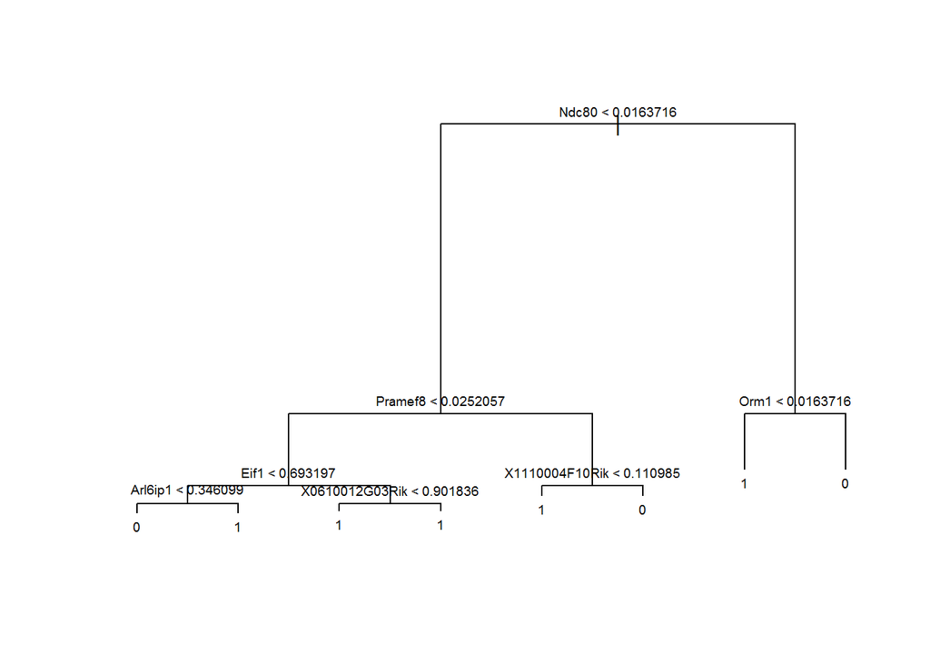

```r
plot(tree.mod.SMOTE)
text(tree.mod.SMOTE,cex=0.6)
```

```r
#"Ndc80"          "Pramef8"        "Eif1"           "Arl6ip1"        "X0610012G03Rik"
#"X1110004F10Rik" "Orm1"

tree.pred.SMOTE<-predict(tree.mod.SMOTE,newdata=test.SMOTE,type = 'class')
tree.pred2.SMOTE<-prediction(as.numeric(tree.pred.SMOTE)-1,Ytest01.SMOTE)
perftree.SMOTE<-performance(tree.pred2.SMOTE,'sens','spec')
#perftree.SMOTE@x.values#speci
#perftree.SMOTE@y.values#sensi
performance(tree.pred2.SMOTE,'auc')@y.values#AUC可以到达0.957!!!
```

```
## [[1]]
## [1] 0.957905
```

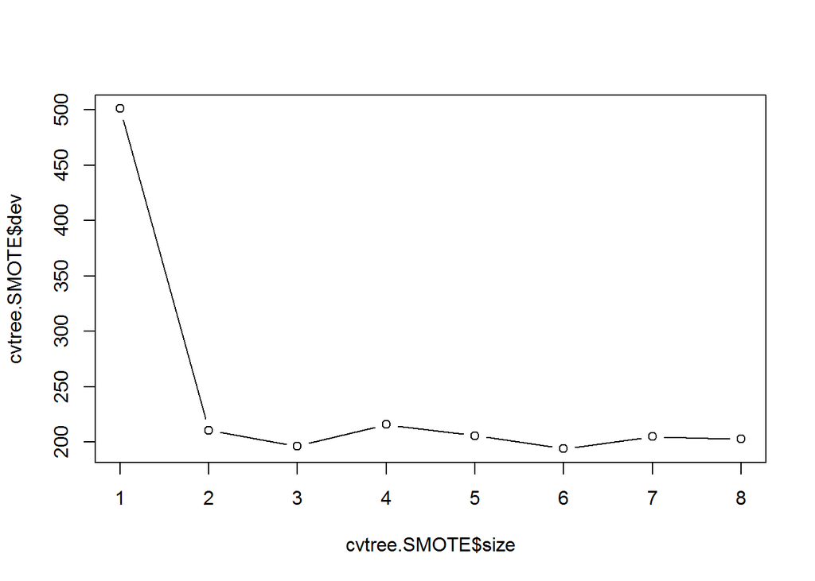

```r
#尝试不同剪枝。这里seed(1)
set.seed(1)
cvtree.SMOTE<-cv.tree(tree.mod.SMOTE,FUN=prune.tree)
plot(cvtree.SMOTE$size,cvtree.SMOTE$dev,type='b')#发现大概在6层
```

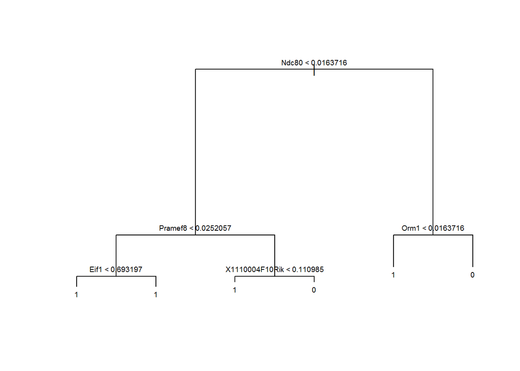

```r
prunetree.SMOTE<-prune.tree(tree.mod.SMOTE,best=6)
plot(prunetree.SMOTE)
text(prunetree.SMOTE,pretty=0,cex=0.6)
```

```r
prunetree.pred.SMOTE<-predict(prunetree.SMOTE,newdata=test.SMOTE,type = 'class')
prunetree.pred2.SMOTE<-prediction(as.numeric(prunetree.pred.SMOTE)-1,Ytest01.SMOTE)
perfprunetree.SMOTE<-performance(prunetree.pred2.SMOTE,'sens','spec')
#perfprunetree.SMOTE@x.values#speci
#perfprunetree.SMOTE@y.values#sensi
performance(prunetree.pred2.SMOTE,'auc')@y.values#AUC可以到达0.966!!!woc简直幸福了
```

```
## [[1]]
## [1] 0.9666574
```

```r
summary(prunetree.SMOTE)
```

```
##
## Classification tree:
## snip.tree(tree = tree.mod.SMOTE, nodes = c(9L, 8L))
## Variables actually used in tree construction:
## [1] "Ndc80"          "Pramef8"        "Eif1"           "X1110004F10Rik"
## [5] "Orm1"
## Number of terminal nodes:  6
## Residual mean deviance:  0.09446 = 33.34 / 353
## Misclassification error rate: 0.0195 = 7 / 359
```

```r
# "Ndc80"          "Pramef8"        "Eif1"   "X1110004F10Rik" "Orm1"
# 这五个基因，重点去看！！


auc.tree.SMOTE<-roc(Ytest01.SMOTE,as.numeric(prunetree.pred.SMOTE)-1)
print(auc.tree.SMOTE)
```

```
##
## Call:
## roc.default(response = Ytest01.SMOTE, predictor = as.numeric(prunetree.pred.SMOTE) -     1)
##
## Data: as.numeric(prunetree.pred.SMOTE) - 1 in 61 controls (Ytest01.SMOTE 0) < 59 cases (Ytest01.SMOTE 1).
## Area under the curve: 0.9667
```

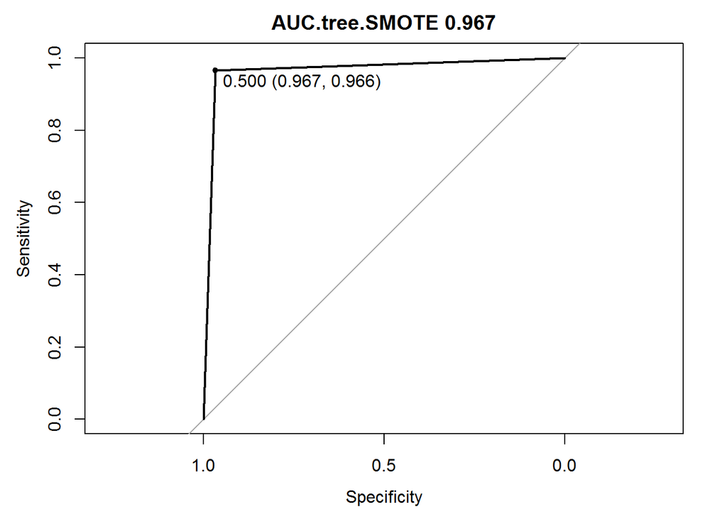

```r
plot(auc.tree.SMOTE,ylim=c(0,1),print.thres=T,main=paste('AUC.tree.SMOTE',round(auc.tree.SMOTE$auc[[1]],3)))
```

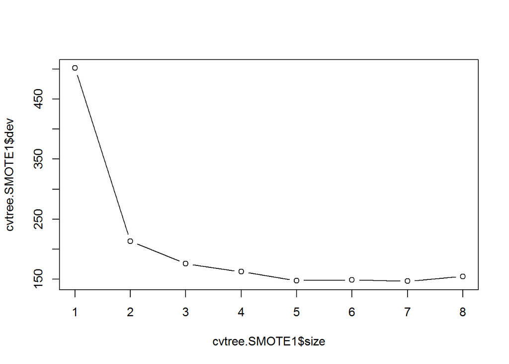

```r
#尝试不同剪枝。这里seed(112233)
set.seed(112233)
cvtree.SMOTE1<-cv.tree(tree.mod.SMOTE,FUN=prune.tree)
plot(cvtree.SMOTE1$size,cvtree.SMOTE1$dev,type='b')#发现大概在7层
```

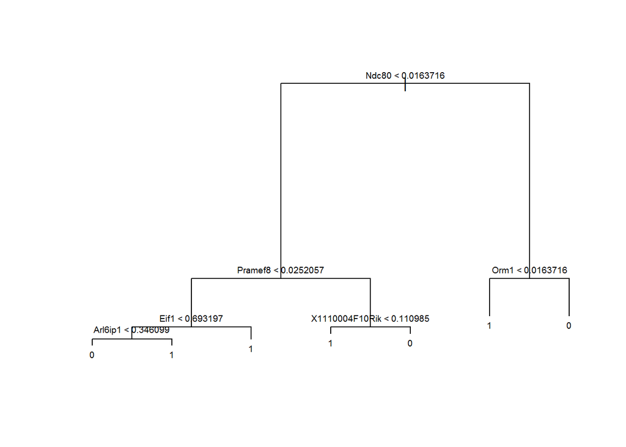

```r
prunetree.SMOTE1<-prune.tree(tree.mod.SMOTE,best=7)
plot(prunetree.SMOTE1)
text(prunetree.SMOTE1,pretty=0,cex=0.6)
```

```r
prunetree.pred.SMOTE1<-predict(prunetree.SMOTE1,newdata=test.SMOTE,type = 'class')
prunetree.pred2.SMOTE1<-prediction(as.numeric(prunetree.pred.SMOTE1)-1,Ytest01.SMOTE)
perfprunetree.SMOTE1<-performance(prunetree.pred2.SMOTE1,'sens','spec')
#perfprunetree.SMOTE@x.values#speci
#perfprunetree.SMOTE@y.values#sensi
performance(prunetree.pred2.SMOTE1,'auc')@y.values#AUC可以到达0.966!!!woc简直幸福了
```

```
## [[1]]
## [1] 0.957905
```

```r
summary(prunetree.SMOTE1)
```

```
##
## Classification tree:
## snip.tree(tree = tree.mod.SMOTE, nodes = 9L)
## Variables actually used in tree construction:
## [1] "Ndc80"          "Pramef8"        "Eif1"           "Arl6ip1"
## [5] "X1110004F10Rik" "Orm1"
## Number of terminal nodes:  7
## Residual mean deviance:  0.06798 = 23.93 / 352
## Misclassification error rate: 0.01114 = 4 / 359
```

```r
auc.tree.SMOTE1<-roc(Ytest01.SMOTE,as.numeric(prunetree.pred.SMOTE1)-1)
print(auc.tree.SMOTE1)
```

```
##
## Call:
## roc.default(response = Ytest01.SMOTE, predictor = as.numeric(prunetree.pred.SMOTE1) -     1)
##
## Data: as.numeric(prunetree.pred.SMOTE1) - 1 in 61 controls (Ytest01.SMOTE 0) < 59 cases (Ytest01.SMOTE 1).
## Area under the curve: 0.9579
```

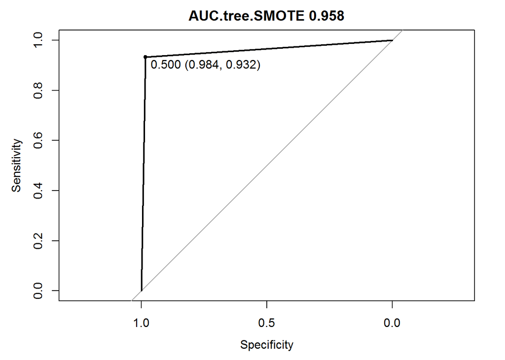

```r
plot(auc.tree.SMOTE1,ylim=c(0,1),print.thres=T,main=paste('AUC.tree.SMOTE',round(auc.tree.SMOTE1$auc[[1]],3)))
```

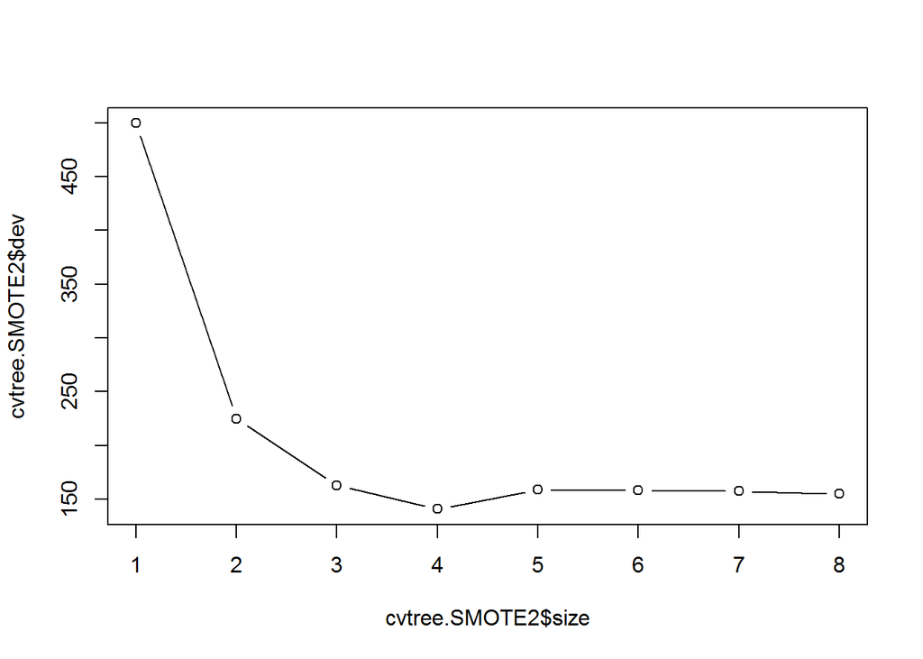

```r
#尝试不同剪枝。这里seed(2)
set.seed(2)
cvtree.SMOTE2<-cv.tree(tree.mod.SMOTE,FUN=prune.tree)
plot(cvtree.SMOTE2$size,cvtree.SMOTE2$dev,type='b')#发现大概在4层
```

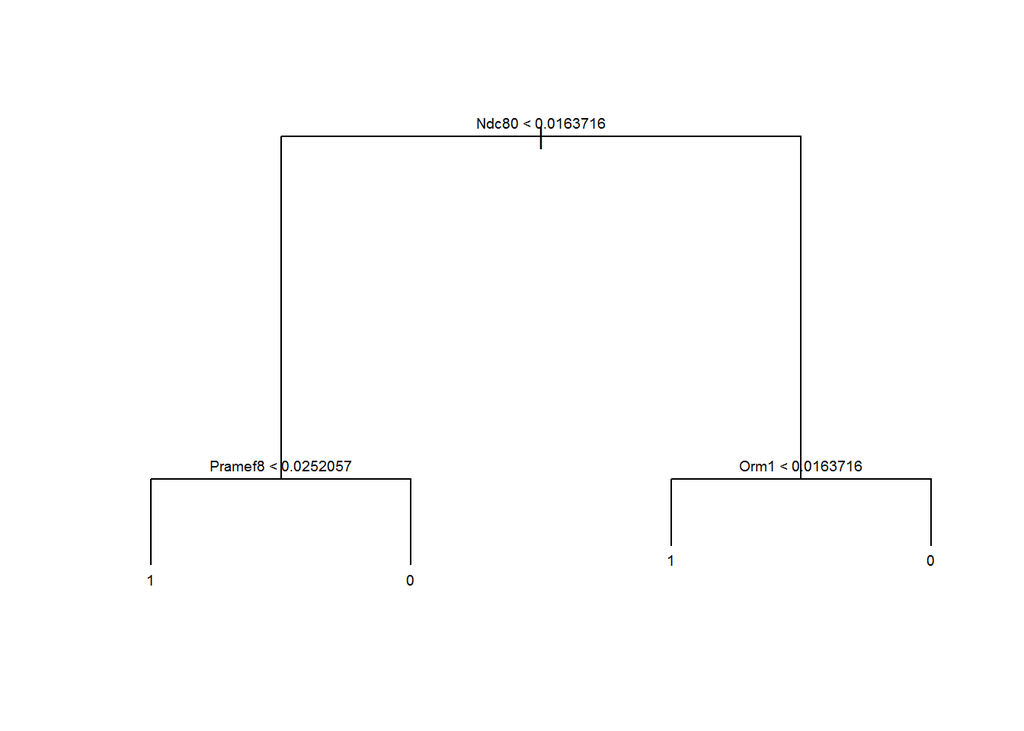

```r
prunetree.SMOTE2<-prune.tree(tree.mod.SMOTE,best=4)
plot(prunetree.SMOTE2)
text(prunetree.SMOTE2,pretty=0,cex=0.6)
```

```r
prunetree.pred.SMOTE2<-predict(prunetree.SMOTE2,newdata=test.SMOTE,type = 'class')
prunetree.pred2.SMOTE2<-prediction(as.numeric(prunetree.pred.SMOTE2)-1,Ytest01.SMOTE)
perfprunetree.SMOTE2<-performance(prunetree.pred2.SMOTE2,'sens','spec')
#perfprunetree.SMOTE@x.values#speci
#perfprunetree.SMOTE@y.values#sensi
performance(prunetree.pred2.SMOTE2,'auc')@y.values#AUC可以到达0.966!!!woc简直幸福了
```

```
## [[1]]
## [1] 0.957905
```

```r
summary(prunetree.SMOTE2)
```

```
##
## Classification tree:
## snip.tree(tree = tree.mod.SMOTE, nodes = c(5L, 4L))
## Variables actually used in tree construction:
## [1] "Ndc80"   "Pramef8" "Orm1"
## Number of terminal nodes:  4
## Residual mean deviance:  0.1755 = 62.32 / 355
## Misclassification error rate: 0.02228 = 8 / 359
```

```r
auc.tree.SMOTE2<-roc(Ytest01.SMOTE,as.numeric(prunetree.pred.SMOTE2)-1)
print(auc.tree.SMOTE2)
```

```
##
## Call:
## roc.default(response = Ytest01.SMOTE, predictor = as.numeric(prunetree.pred.SMOTE2) -     1)
##
## Data: as.numeric(prunetree.pred.SMOTE2) - 1 in 61 controls (Ytest01.SMOTE 0) < 59 cases (Ytest01.SMOTE 1).
## Area under the curve: 0.9579
```

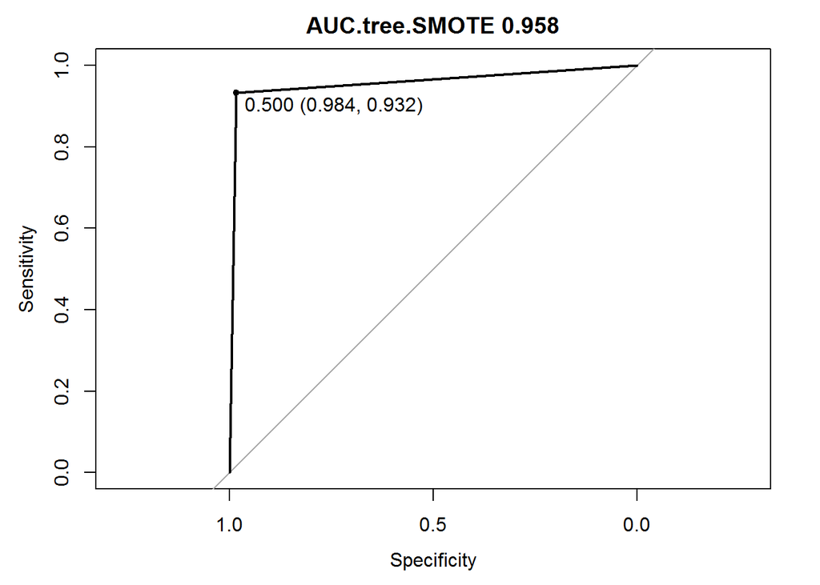

```r
plot(auc.tree.SMOTE2,ylim=c(0,1),print.thres=T,main=paste('AUC.tree.SMOTE',round(auc.tree.SMOTE2$auc[[1]],3)))
```

整体来看，决策树剪枝选变量还是比较稳健的。可以说明一些问题。 “Ndc80” “Pramef8” “Eif1” “Arl6ip1” “X1110004F10Rik” “Orm1”等。重点去看

### 集成、SVM等方法达到了非常优的水平！提升空间非常大

```r
#5.SVM，不太好解释，但also效果好的一匹
library(e1071)
#wts.SMOTE<-100/table(Ytrain01.SMOTE)
svmfit.SMOTE<-svm(Ytrain01.SMOTE~.,data = train.SMOTE, scale=F,kernel = "radial",probability=T)
            #,class.weights=wts.SMOTE)
summary(svmfit.SMOTE)
```

```
##
## Call:
## svm(formula = Ytrain01.SMOTE ~ ., data = train.SMOTE, kernel = "radial",
##     probability = T, scale = F)
##
##
## Parameters:
##    SVM-Type:  C-classification
##  SVM-Kernel:  radial
##        cost:  1
##       gamma:  0.0001660854
##
## Number of Support Vectors:  190
##
##  ( 120 70 )
##
##
## Number of Classes:  2
##
## Levels:
##  0 1
```

```r
svm.pred.SMOTE<-predict(svmfit.SMOTE,newdata = test.SMOTE)
svm.pred2.SMOTE<-prediction(as.numeric(svm.pred.SMOTE)-1,Ytest01.SMOTE)
perfsvm.SMOTE<-performance(svm.pred2.SMOTE,'sens','spec')
#perfsvm.SMOTE@x.values#speci
#perfsvm.SMOTE@y.values#sensi
performance(svm.pred2.SMOTE,'auc')@y.values#AUC is 1
```

```
## [[1]]
## [1] 1
```

```r
#6.RF
rf.SMOTE <- randomForest(Ytrain01.SMOTE~., data=train.SMOTE, ntree=100, proximity=TRUE,importance=TRUE)
sort(importance(rf.SMOTE,type = 1),decreasing = T)[1:20]
```

```
##  [1] 2.120346 2.103017 1.983679 1.933581 1.930853 1.884424 1.875036
##  [8] 1.753903 1.749090 1.742650 1.730293 1.715936 1.710460 1.709892
## [15] 1.699041 1.693528 1.657717 1.615563 1.606756 1.572938
```

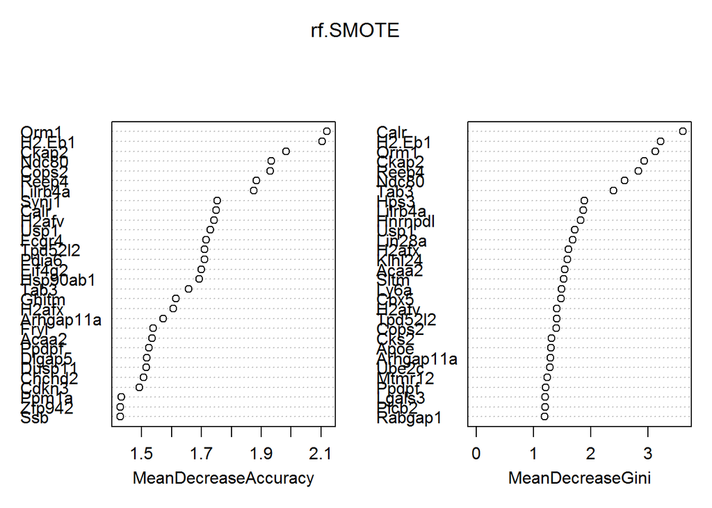

```r
varImpPlot(rf.SMOTE)
```

```r
rf.pred.SMOTE<-predict(rf.SMOTE,newdata = test.SMOTE)
length(rf.pred.SMOTE)
```

```
## [1] 120
```

```r
rf.pred2.SMOTE<-prediction(as.numeric(rf.pred.SMOTE)-1,Ytest01.SMOTE)
perfrf.SMOTE<-performance(rf.pred2.SMOTE,'sens','spec')
#perfrf.SMOTE@x.values#speci
#perfrf.SMOTE@y.values#sensi
performance(rf.pred2.SMOTE,'auc')@y.values#AUC 0.99
```

```
## [[1]]
## [1] 0.9918033
```

## 方向一的总结：

### SMOTE前

1.SMOTE前的方法中

①SCAD方法得到结果：Calr Gzma Ccl5 Hspa5 Snx19 （改变不同的set.seed稳定，只是shrinkage出来的个数不同）

②.tree方法：（但分类结果非常差，所以仅供参考）

③集成方法importance：（但同理，分类结果非常差）

### SMOTE后

2.SMOTE后的方法中：（试过不同SET.SEED看看是不是稳健的）

①SCAD的Ccl5 Calr Lgals3 Hspa5 Gpatch2l Axin1 Ipo8 Klf2 Chmp5， 同理，看看不同set.seed是否稳定

③集成方法importance：

### Gene Card:

https://www.genecards.org/cgi-bin/carddisp.pl?gene=NDC80

1. NDC80:与染色体分离有关。This gene encodes a component of the NDC80 kinetochore complex. The encoded protein consists of an N-terminal microtubule binding domain and a C-terminal coiled-coiled domain that interacts with other components of the complex. This protein functions to organize and stabilize microtubule-kinetochore interactions and is required for proper chromosome segregation. [provided by RefSeq, Oct 2011]

2.Pramef8 也为蛋白质编码基因

3.Calr：转录调控有关。Calreticulin is a multifunctional protein that acts as a major Ca(2+)-binding (storage) protein in the lumen of the endoplasmic reticulum. It is also found in the nucleus, suggesting that it may have a role in transcription regulation. Calreticulin binds to the synthetic peptide KLGFFKR, which is almost identical to an amino acid sequence in the DNA-binding domain of the superfamily of nuclear receptors. Calreticulin binds to antibodies in certain sera of systemic lupus and Sjogren patients which contain anti-Ro/SSA antibodies, it is highly conserved among species, and it is located in the endoplasmic and sarcoplasmic reticulum where it may bind calcium. The amino terminus of calreticulin interacts with the DNA-binding domain of the glucocorticoid receptor and prevents the receptor from binding to its specific glucocorticoid response element. Calreticulin can inhibit the binding of androgen receptor to its hormone-responsive DNA element and can inhibit androgen receptor and retinoic acid receptor transcriptional activities in vivo, as well as retinoic acid-induced neuronal differentiation. Thus, calreticulin can act as an important modulator of the regulation of gene transcription by nuclear hormone receptors. Systemic lupus erythematosus is associated with increased autoantibody titers against calreticulin but calreticulin is not a Ro/SS-A antigen. Earlier papers referred to calreticulin as an Ro/SS-A antigen but this was later disproven. Increased autoantibody titer against human calreticulin is found in infants with complete congenital heart block of both the IgG and IgM classes. [provided by RefSeq, Jul 2008]

4.RIK gene似乎都搜索不到。是否是长链非编码RNA？较可疑。但老师的说法是这一块我们都先不看了

# 方向二：多重假设检验

```r
#先看正态性
P<-rep(0,ncol(X))
for (i in 1:ncol(X)) {
  P[i]<-shapiro.test(X[,i])$p.value
}
SigP<-P[order(P,decreasing = T)[1:400]]
SigP
```

```
##   [1] 3.340043e-01 4.192261e-02 4.119793e-03 8.361282e-04 6.875197e-04
##   [6] 4.121565e-04 1.302238e-04 1.730009e-05 7.395266e-06 5.154426e-06
##  [11] 2.233131e-06 7.959030e-07 6.946846e-07 2.252406e-07 2.227618e-07
##  [16] 2.015629e-07 1.116477e-07 5.350918e-08 5.149250e-08 3.591262e-08
##  [21] 1.904797e-08 1.155745e-08 8.955013e-09 6.954930e-09 5.119713e-09
##  [26] 4.269094e-09 3.468488e-09 3.071055e-09 2.574820e-09 1.779442e-09
##  [31] 1.765740e-09 1.675480e-09 6.982235e-10 4.402105e-10 4.387539e-10
##  [36] 4.079125e-10 3.682518e-10 2.938088e-10 2.536298e-10 2.112742e-10
##  [41] 2.072762e-10 1.673190e-10 1.559419e-10 1.465621e-10 1.440240e-10
##  [46] 1.139837e-10 1.135784e-10 1.024327e-10 9.655528e-11 9.438369e-11
##  [51] 9.272008e-11 8.539829e-11 7.560578e-11 7.384443e-11 6.771014e-11
##  [56] 5.364223e-11 4.734508e-11 4.677485e-11 4.498915e-11 3.257966e-11
##  [61] 3.206873e-11 3.165327e-11 2.873102e-11 2.681262e-11 2.647358e-11
##  [66] 2.425994e-11 2.231578e-11 2.225411e-11 2.171514e-11 1.950994e-11
##  [71] 1.902840e-11 1.901333e-11 1.897740e-11 1.629519e-11 1.593486e-11
```

[output cut: 65 more lines]

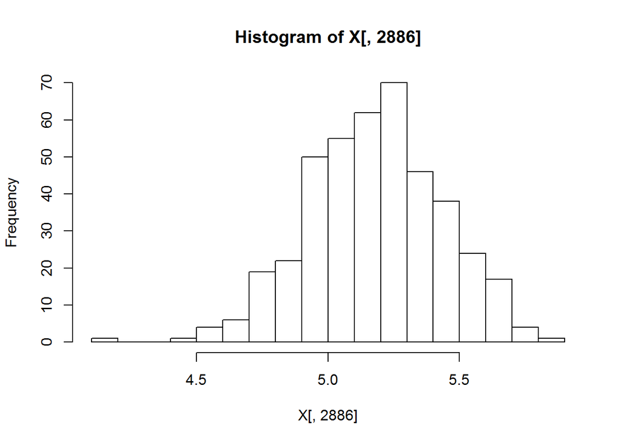

```r
hist(X[,2886],breaks = 20)
```

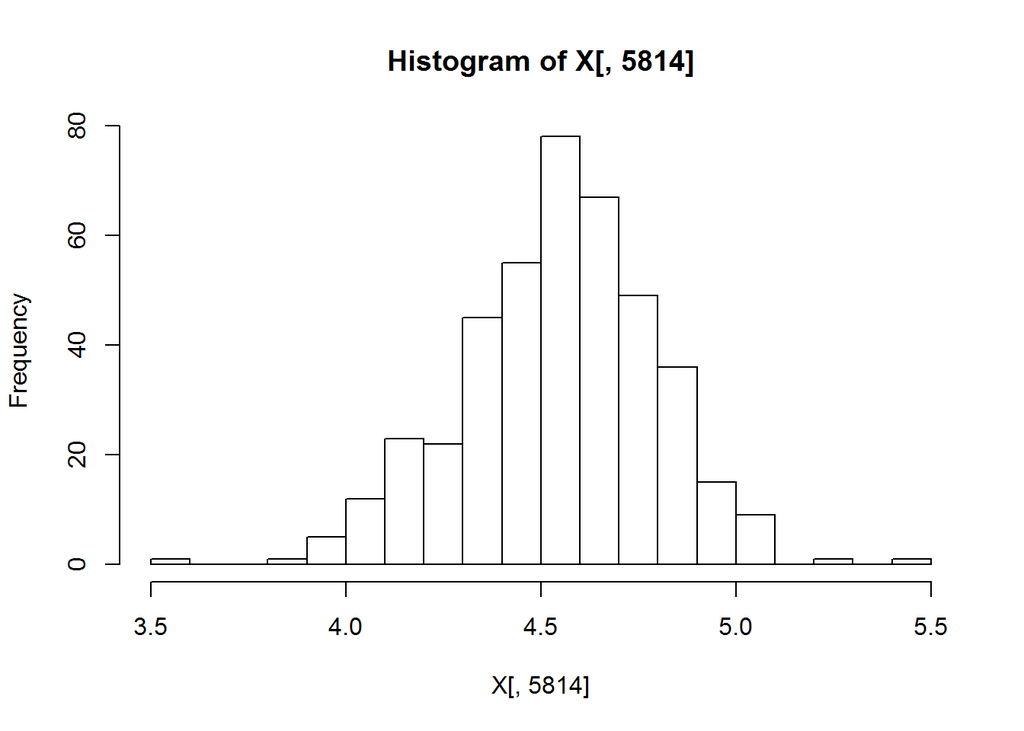

```r
hist(X[,5814],breaks = 20)
```

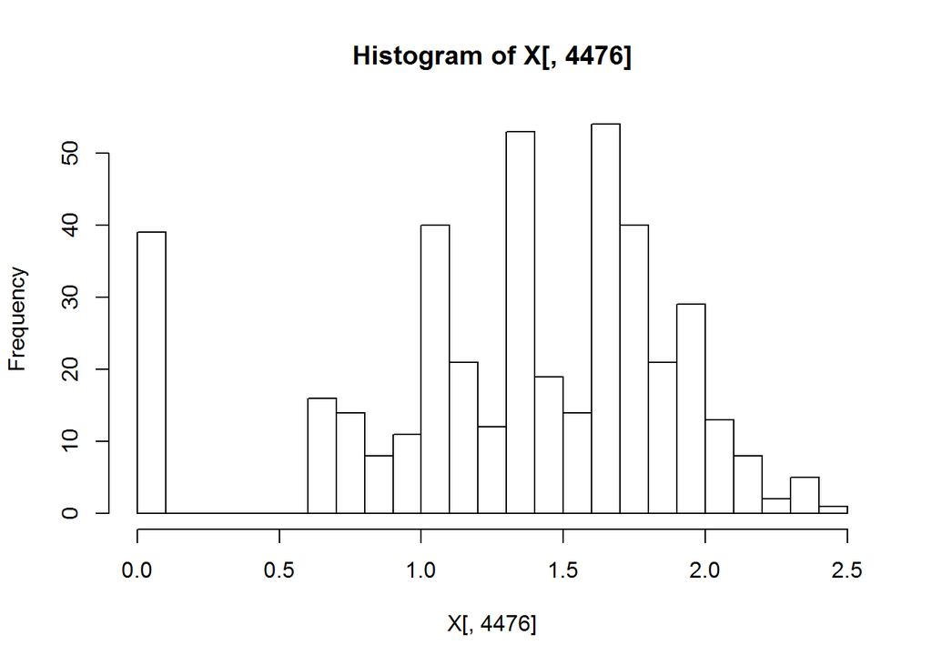

```r
hist(X[,4476],breaks = 20)
```

```r
#FDR
PFDR<-p.adjust(P,method = 'fdr',n=length(P))
SigPFDR<-PFDR[order(PFDR,decreasing = T)[1:400]]


#distribution????

a<-sum(data[,2:ncol(data)]!=0)
b<-sum(data[,2:ncol(data)]==0)
a
```

```
## [1] 844896
```

```r
b
```

```
## [1] 6264024
```

```r
a/b
```

```
## [1] 0.1348807
```

```r
a/(a+b)
```

```
## [1] 0.1188501
```

```r
rdata<-data[,2:ncol(data)]
aa<-c(rdata[rdata==0],rdata[rdata!=0])
#class(aa)
#summary(aa)
#length(aa)
table(aa[aa!=0])[1:100]
```

[output not shown]

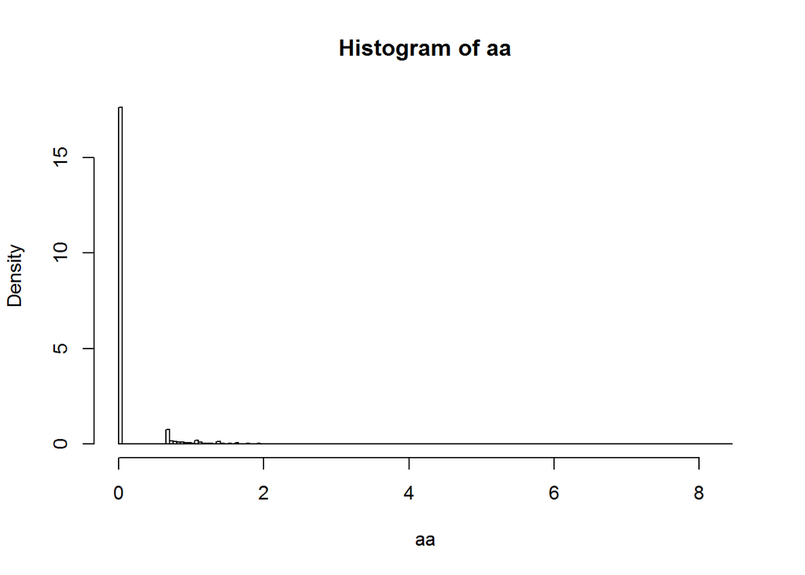

```r
hist(aa,breaks=200,freq = F)#这分布太可怕了
```

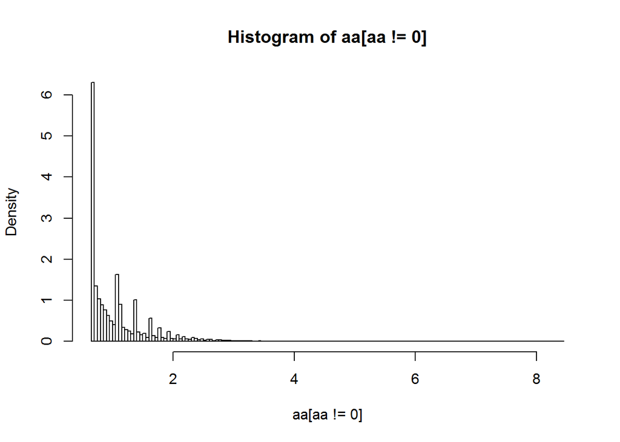

```r
hist(aa[aa!=0],breaks=200,freq = F)#这分布太可怕了
```

```r
#which.max(aa)
```

# 总结

当然，以上的所有统计方法都只能做个初步的参考作用，从16000个基因里缩小搜索范围。进一步的研究是需要生物学背景支持的。数据不能完全代替人。

所有模型都是错的。说不定这里找的所有因子和分类也是错的。真正起作用的是在数据集里没有体现出来的某个基因。

# 下一步：

1.(i)解决TSNE问题的标记问题（重要！！！）以及表格标尺的问题,还有不同的set.seed后TSNE也不一样+(ii)解决FPR的原始标记问题+(iii)PCA降维一下看看（这里是为了看看预测问题会不会受到SMOTE的影响。FPR必须为0.TPR越高越好）(iv)不同setseed对shrinkage和决策树、集成方法等的影响。甚至是不同setseed对不同SMOTE后数据的影响。选出来的变量等(v)用SMOTE后importance选出来的变量人工做个LR啊

2. 多重假设检验FDR。先看看是否为正态性.树方法、LASSO方法、和FDR结果筛选变量是否一致。变量一致的时候再检验阈值的稳健性（这一步是检验变量选择和阈值训练的稳定性）

*3.多分类+XGBOOST方法尝试一下(SMOTE前后都要)（目前略）

*4.开始了解不同潜在的基因生物学背景，Gene Card。简单点就好。特别是查RIK（RIK不用查了，其他给老师）

*5.稀疏性/零膨胀问题会不会对logistics产生影响。数据噪音会不会对决策树有影响等（暂时不考虑对方向一的影响，方向二的影响肯定有）

*6.SIS,KF等screening的方法再试一下（方向一可以尝试，先省略）

7.repulicate 文献方法.主要concern的有

（1）使用除了SMOTE方法以外解决非平衡问题的方法（Voronoi diagrams,V-synth合成方法）

（2）解决测序数据噪声。 ————Multiplatform single-sample estimates of transcriptional activation ————Bayesian approach to single-cell differential expression analysis

（3）新的聚类方法（提供可视化工具）————sc3: consensus clustering of single-cell rna-seq data。这个可以主要考虑一下

（4）针对零膨胀问题的数据降维（大量dropout导致零膨胀，之前都没有做过处理）————ZIFA: Dimensionality reduction for zero-inflated single-cell gene expression analysis

（5）针对数据本身，可能来自于不同细胞阶段，需要鉴定亚群、阶段（即不再是IID了）————Computational analysis of cell-to-cell heterogeneity in single-cell RnA-sequencing data reveals hidden subpopulations of cells